# Utilization Outcomes for Home Health Agencies

**Aim** Determining the aspects of Home Health Agencies related to lower and higher utilization outcomes namely Hospital Admission rate and Emergency Room Visit rate.

This can facilitate suggestions to focus on and prioritize improvement initiatives. The project aims to study models which help in understanding the characteristics of HHAs such as timely care, check depression, etc. associated with utilization outcomes.

Importing the required libraries

```r
library(rpart)
library(rpart.plot)
library('scales')
library(tree)
library(dplyr)
library(Rmisc)
library(corrplot)
library(naniar)
library(nlme)
library(ggplot2)
library(e1071)
library(leaps)
```

Setting the present working directory to the location where the data is stored and loading the data

```r
setwd("D:/Project/Data")
```

```
The working directory was changed to D:/Project/Data inside a notebook chunk. The working directory will be reset when the chunk is finished running. Use the knitr root.dir option in the setup chunk to change the working directory for notebook chunks.
```

```r
mytypes <- c('character','factor',rep('character',2),'factor',rep('character',2),rep('factor',7),'character',rep('numeric',18),rep('factor',2),rep('numeric',6))
mynames <- c('CCN','state','name','address','city','Zip','phone','type','off.nursing','off.physical','off.occupational','off.speech','off.medical','off.hha','date','rating','ER','taughtdrugs','checkfall','checkdepression','flushot','pnumococcal','taughtfootcare','betterwalking','betterbed','betterbathing','lesspain','betterbreathing','betterheal','betterdrug','admitted','ER','episode','star','year','season','timeindex','median','mean','pop','ruca')
complete_data <- read.csv("completedata.csv",sep=',')
```

Displaying the dimensions of the data and the feature names

```r
dim(complete_data)
```

```
[1] 477164     41
```

```r
names(complete_data)
```

```
 [1] "Zip"              "CCN"              "state"            "name"             "address"          "city"
 [7] "phone"            "type"             "off.nursing"      "off.physical"     "off.occupational" "off.speech"
[13] "off.medical"      "off.hha"          "date"             "rating"           "timely"           "taughtdrugs"
[19] "checkfall"        "checkdepression"  "flushot"          "pnumococcal"      "taughtfootcare"   "betterwalking"
[25] "betterbed"        "betterbathing"    "lesspain"         "betterbreathing"  "betterheal"       "betterdrug"
[31] "admitted"         "ER"               "episode"          "star"             "year"             "season"
[37] "timeindex"        "median"           "mean"             "pop"              "ruca"
```

For convenience purpose I have renamed a few columns:

Zip - Zip Code of Home Health Agency

CCN - CMS Certification Number state

name - Name of the Home Health Agency

address

city

phone

type - Type of Ownership

off.nursing - Offers Nursing Care Services

off.physical - Offers Physical Therapy Services

off.occupational - Offers Occupational Therapy Services

off.speech - Offers Speech Pathology Services

off.medical - Offers Medical Social Services

off.hha - Offers Home Health Aide Services

date - Date Certified

rating - Quality of patient care star rating

timely - How often the home health team began their patients’ care in a timely manner

taughtdrugs - How often the home health team taught patients (or their family caregivers) about their drugs

checkfall - How often the home health team checked patients’ risk of falling

checkdepression - How often the home health team checked patients for depression

flushot - How often the home health team determined whether patients received a flu shot for the current flu season

pneumococcal - How often the home health team determined whether their patients received a pneumococcal vaccine

taughtfootcare - How often the home health team got doctor’s orders, gave foot care, and taught patients about foot care

betterwalking - How often patients got better at walking or moving around

bettered - How often patients got better at getting in and out of bed

betterbathing - How often patients got better at bathing

lesspain - How often patients had less pain when moving around

betterbreathing - How often patients’ breathing improved

betterheal - How often patients’ wounds improved or healed after an operation

betterdrug - How often patients got better at taking their drugs correctly by mouth

admitted - How often home health patients had to be admitted to the hospital

ER - How often patients receiving home health care needed urgent, unplanned care in the ER without being admitted

ruca - Gives information whether it is an Urban HHA or Rural

episode - The episode indicates how many patients and how much workload an HHA finishes every year, which can be used to suggest the size of an HHA to some extend.

mean - mean household income in that zip code

median- median household income in that zip code

*Displaying a sample of data*

```r
head(complete_data)
```

|  | Zip | CCN | state | name | address | city | phone | type | off.nursing | off.physical | off.occupational | off.speech | off.medical | off.hha | date | rating | timely | taughtdrugs | checkfall | checkdepression | flushot | pnumococcal | taughtfootcare | betterwalking | betterbed | betterbathing | lesspain | betterbreathing | betterheal | … |
| --- | --- | --- | --- | --- | --- | --- | --- | --- | --- | --- | --- | --- | --- | --- | --- | --- | --- | --- | --- | --- | --- | --- | --- | --- | --- | --- | --- | --- | --- | --- |
| 1 | 601 | 407024 | PR | CUIDADO CASERO EL GIGANTE | RODULFO GONZALEZ #66 ESQUINA CONCORDIA | ADJUNTAS | 7878297710 | VOLUNTARY NON-PROFIT - PRIVATE | Y | Y | N | Y | Y | Y | 7/5/1988 | NA | 86.0 | 92.0 | 100.0 | 100.0 | 13.0 | 12.0 | 100.0 | 55.0 | 57.0 | 70.0 | 80.0 | 66.0 | 91.0 | … |
| 2 | 601 | 407024 | PR | METRO PAVIA AT HOME ADJUNTAS | RODULFO GONZALEZ STREET #66 | ADJUNTAS | 7878297710 | Proprietary | Yes | Yes | Yes | Yes | Yes | Yes | 1988-07-05 00:00:00 | 3.5 | 87.0 | 99.5 | 99.3 | 96.6 | 24.3 | 9.8 | 99.0 | 81.4 | 73.7 | 80.1 | 93.9 | 88.6 | 93.2 | … |
| 3 | 601 | 407024 | PR | CUIDADO CASERO EL GIGANTE | RODULFO GONZALEZ #66 ESQUINA CONCORDIA | ADJUNTAS | 7878297710 | VOLUNTARY NON-PROFIT - PRIVATE | Y | Y | N | Y | Y | Y | 7/5/1988 | NA | 90.0 | 95.0 | 100.0 | 100.0 | 13.0 | 12.0 | 100.0 | 58.0 | 58.0 | 71.0 | 78.0 | 73.0 | 89.0 | … |
| 4 | 601 | 407024 | PR | CUIDADO CASERO EL GIGANTE | RODULFO GONZALEZ #66 ESQUINA CONCORDIA | ADJUNTAS | 7878297710 | Voluntary Non Profit - Private | Y | Y | N | N | Y | Y | 7/5/1988 0:00:00 | NA | NA | NA | NA | NA | NA | NA | NA | 59.0 | 68.0 | 79.0 | 87.0 | NA | NA | … |
| 5 | 601 | 407024 | PR | METRO PAVIA AT HOME ADJUNTAS | RODULFO GONZALEZ STREET #66 | ADJUNTAS | 7878297710 | Non - Profit Private | Yes | Yes | No | No | Yes | Yes | 1988-07-05 00:00:00 | 3.5 | 98.6 | 95.3 | 99.3 | 98.9 | 15.7 | 8.9 | 97.4 | 98.7 | 99.6 | 96.5 | 65.5 | 62.8 | 69.8 | … |
| 6 | 601 | 407024 | PR | CUIDADO CASERO EL GIGANTE | RODULFO GONZALEZ #66 ESQUINA CONCORDIA | ADJUNTAS | 7878297710 | Private | Yes | Yes | No | No | Yes | Yes | 1988-07-05 00:00:00 | NA | 98.0 | 94.0 | 99.0 | 100.0 | 12.0 | 13.0 | 100.0 | 65.0 | 64.0 | 70.0 | 85.0 | 73.0 | 95.0 | … |

The rural-urban commuting area (RUCA) codes classify U.S. census tracts using measures of population density, urbanization, and daily commuting. The classification contains two levels. Whole numbers (1-10) delineate metropolitan, micropolitan, small town, and rural commuting areas based on the size and direction of the primary (largest) commuting flows. These 10 codes are further subdivided based on secondary commuting flows, providing flexibility in combining levels to meet varying definitional needs and preferences[[1](https://www.ers.usda.gov/data-products/rural-urban-commuting-area-codes/)]. According to code definations code 1 implies that the ZIP code is Ubran and all other codes fall under Rural. Therefore converting them into Urban and Rural and making the feature a categorical column.

```r
table(complete_data$ruca)
```

```
     1    1.1      2    2.1      3      4    4.1    4.2      5    5.1    5.2      6      7    7.1    7.2    7.3    7.4
339236   2903  12963    355    497  31421   1711   7107   1590      7    104    259  19789   1246    407   5008   2897
     8    8.1    8.2    8.3    8.4      9    9.1    9.2     10   10.1   10.2   10.3   10.4   10.5   10.6
  1732     17    118     44     40    464     69     17   7327    253    473    151   1510   2443   2527
```

```r
complete_data$ruca[complete_data$ruca==1] <- "Urban"
complete_data$ruca[complete_data$ruca!='Urban'] <- "Rural"

table(complete_data$ruca)
```

```
 Rural  Urban
105449 339236
```

```r
dummyruca <- as.factor(complete_data$ruca)
complete_data$ruca <- dummyruca

complete_data[complete_data==199|complete_data==201]<-NA
complete_data[complete_data==5030353|complete_data==16665138]<-NA
```

Few of the columns have same values represented in multiple ways for example the column named off.nursing has two values for Yes represented as strings “Y” and “Yes”. Converting such values to 0 and 1 and changing the datatype of the columns to categorical.

```r
complete_data$off.nursing[complete_data$off.nursing == 'Y'] <- 1
complete_data$off.nursing[complete_data$off.nursing == 'Yes'] <- 1
complete_data$off.physical[complete_data$off.physical == 'Y'] <- 1
complete_data$off.physical[complete_data$off.physical == 'Yes'] <- 1
complete_data$off.physical[complete_data$off.physical == 'N'] <- 0
complete_data$off.physical[complete_data$off.physical == 'No'] <- 0

complete_data$off.occupational[complete_data$off.occupational == 'Y'] <- 1
complete_data$off.occupational[complete_data$off.occupational == 'Yes'] <- 1
complete_data$off.occupational[complete_data$off.occupational == 'N'] <- 0
complete_data$off.occupational[complete_data$off.occupational == 'No'] <- 0

complete_data$off.speech[complete_data$off.speech == 'Y'] <- 1
complete_data$off.speech[complete_data$off.speech == 'Yes'] <- 1
complete_data$off.speech[complete_data$off.speech == 'N'] <- 0
complete_data$off.speech[complete_data$off.speech == 'No'] <- 0

complete_data$off.medical[complete_data$off.medical == 'Y'] <- 1
complete_data$off.medical[complete_data$off.medical == 'Yes'] <- 1
complete_data$off.medical[complete_data$off.medical == 'N'] <- 0
complete_data$off.medical[complete_data$off.medical == 'No'] <- 0

complete_data$off.hha[complete_data$off.hha == 'Y'] <- 1
complete_data$off.hha[complete_data$off.hha == 'Yes'] <- 1
complete_data$off.hha[complete_data$off.hha == 'N'] <- 0
complete_data$off.hha[complete_data$off.hha == 'No'] <- 0


complete_data$off.physical <- as.factor(complete_data$off.physical)
complete_data$off.occupational <- as.factor(complete_data$off.occupational)
complete_data$off.speech <- as.factor(complete_data$off.speech)
complete_data$off.medical <- as.factor(complete_data$off.medical)
complete_data$off.hha <- as.factor(complete_data$off.hha)
complete_data$type <- as.factor(complete_data$type)
complete_data$CCN <- as.factor(complete_data$CCN)
complete_data$star <- as.factor(complete_data$star)
complete_data$year <- as.factor(complete_data$year)
```

Visualizing the datatypes of features in the data

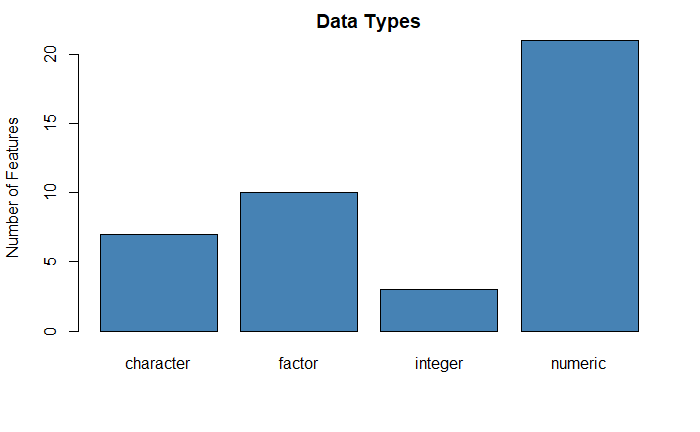

```r
#The datatypes of columns currently present in the dataframe
data_types <- function(frame) {
  res <- lapply(frame, class)
  res_frame <- data.frame(unlist(res))
  barplot(table(res_frame), main="Data Types", col="steelblue", ylab="Number of Features")
}

#This displays a plot of the datatype of features
#Reference - https://stackoverflow.com/questions/21125222/determine-the-data-types-of-a-data-frames-columns
data_types(complete_data)
```

Visualizing the missing values to understand if there is any pattern in the data.

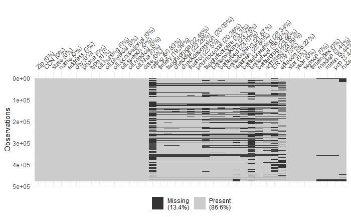

```r
vis_miss(complete_data, warn_large_data = FALSE)
```

Since this is a regression problem and there are a lot of missing values in the data I first thought of removing the columns which are highly correlated with each other. I plotted a correlation matrix to understand if there is any correlation between the features.

```r
complete_data <- data.frame(complete_data[,c(1:8,10:15)],complete_data[,c(17:28)],complete_data[,c(30:41)])
names(complete_data)
```

```
 [1] "Zip"              "CCN"              "state"            "name"             "address"          "city"
 [7] "phone"            "type"             "off.physical"     "off.occupational" "off.speech"       "off.medical"
[13] "off.hha"          "date"             "timely"           "taughtdrugs"      "checkfall"        "checkdepression"
[19] "flushot"          "pnumococcal"      "taughtfootcare"   "betterwalking"    "betterbed"        "betterbathing"
[25] "lesspain"         "betterbreathing"  "betterdrug"       "admitted"         "ER"               "episode"
[31] "star"             "year"             "season"           "timeindex"        "median"           "mean"
[37] "pop"              "ruca"
```

```r
complete_data_withoutnull <- na.omit(complete_data)
res <- cor(data.frame(complete_data_withoutnull[,c(15:30)],complete_data_withoutnull[,c(35:37)]))
round(res, 2)
```

```
                timely taughtdrugs checkfall checkdepression flushot pnumococcal taughtfootcare betterwalking betterbed
timely            1.00        0.22      0.08            0.15    0.18        0.20           0.16          0.15      0.13
taughtdrugs       0.22        1.00      0.19            0.22    0.16        0.19           0.43          0.17      0.14
checkfall         0.08        0.19      1.00            0.14    0.06        0.07           0.15          0.13      0.12
checkdepression   0.15        0.22      0.14            1.00    0.11        0.12           0.19          0.10      0.09
flushot           0.18        0.16      0.06            0.11    1.00        0.82           0.15          0.10      0.13
pnumococcal       0.20        0.19      0.07            0.12    0.82        1.00           0.17          0.12      0.15
taughtfootcare    0.16        0.43      0.15            0.19    0.15        0.17           1.00          0.15      0.12
betterwalking     0.15        0.17      0.13            0.10    0.10        0.12           0.15          1.00      0.88
betterbed         0.13        0.14      0.12            0.09    0.13        0.15           0.12          0.88      1.00
betterbathing     0.16        0.15      0.12            0.12    0.13        0.13           0.10          0.89      0.85
lesspain          0.24        0.21      0.10            0.14    0.19        0.15           0.14          0.30      0.27
betterbreathing   0.17        0.15      0.05            0.09    0.30        0.27           0.11          0.28      0.31
betterdrug        0.18        0.20      0.10            0.10    0.28        0.27           0.15          0.39      0.38
admitted          0.00       -0.06     -0.10           -0.02    0.04        0.04          -0.03         -0.10     -0.08
ER                0.02        0.00     -0.01           -0.01    0.11        0.16           0.02          0.04      0.06
episode           0.01        0.00     -0.01            0.00   -0.01       -0.01           0.00          0.00     -0.01
median           -0.04        0.02      0.01           -0.01    0.00       -0.02           0.00          0.01      0.02
mean             -0.03        0.02      0.01           -0.01    0.00       -0.01           0.00          0.01      0.02
pop              -0.02        0.02      0.01           -0.01   -0.10       -0.12           0.02         -0.04     -0.06
                betterbathing lesspain betterbreathing betterdrug admitted    ER episode median  mean   pop
timely                   0.16     0.24            0.17       0.18     0.00  0.02    0.01  -0.04 -0.03 -0.02
taughtdrugs              0.15     0.21            0.15       0.20    -0.06  0.00    0.00   0.02  0.02  0.02
checkfall                0.12     0.10            0.05       0.10    -0.10 -0.01   -0.01   0.01  0.01  0.01
checkdepression          0.12     0.14            0.09       0.10    -0.02 -0.01    0.00  -0.01 -0.01 -0.01
flushot                  0.13     0.19            0.30       0.28     0.04  0.11   -0.01   0.00  0.00 -0.10
pnumococcal              0.13     0.15            0.27       0.27     0.04  0.16   -0.01  -0.02 -0.01 -0.12
taughtfootcare           0.10     0.14            0.11       0.15    -0.03  0.02    0.00   0.00  0.00  0.02
betterwalking            0.89     0.30            0.28       0.39    -0.10  0.04    0.00   0.01  0.01 -0.04
betterbed                0.85     0.27            0.31       0.38    -0.08  0.06   -0.01   0.02  0.02 -0.06
betterbathing            1.00     0.39            0.35       0.43    -0.08  0.01    0.00   0.02  0.03 -0.04
lesspain                 0.39     1.00            0.71       0.60    -0.04 -0.05    0.00   0.09  0.08 -0.01
betterbreathing          0.35     0.71            1.00       0.69     0.01  0.05   -0.01   0.08  0.08 -0.10
betterdrug               0.43     0.60            0.69       1.00    -0.02  0.08    0.00   0.04  0.05 -0.10
admitted                -0.08    -0.04            0.01      -0.02     1.00 -0.09    0.00  -0.05 -0.05 -0.09
ER                       0.01    -0.05            0.05       0.08    -0.09  1.00    0.00  -0.11 -0.11 -0.14
episode                  0.00     0.00           -0.01       0.00     0.00  0.00    1.00   0.00  0.01  0.00
median                   0.02     0.09            0.08       0.04    -0.05 -0.11    0.00   1.00  0.96  0.10
mean                     0.03     0.08            0.08       0.05    -0.05 -0.11    0.01   0.96  1.00  0.04
pop                     -0.04    -0.01           -0.10      -0.10    -0.09 -0.14    0.00   0.10  0.04  1.00
```

```r
#Dropping highly correlated features
complete_data <- data.frame(complete_data[,c(1:18)],complete_data[,c(20:21)], complete_data[,c(24:35,38)])
```

Plotting the data for missingness after dropping the highly correlated columns. Since there is no significant evidence for why data is missing and there is pattern observed I decided to drop the missing values.

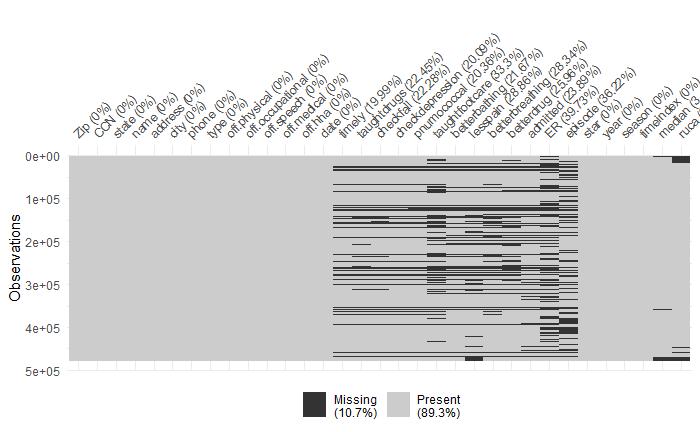

```r
vis_miss(complete_data, warn_large_data = FALSE)
```

Since my analysis involves two utilization outcomes: Admission Rate and Emergency Room Visit Rate, I have created two dataframes one for admission rate and other for emergency room visit rate.

```r
admitted <- data.frame(complete_data[,c(9:13)],complete_data[,c(15:25)],complete_data[,c(27,30,31,32,33)])
names(admitted)
```

```
 [1] "off.physical"     "off.occupational" "off.speech"       "off.medical"      "off.hha"          "timely"
 [7] "taughtdrugs"      "checkfall"        "checkdepression"  "pnumococcal"      "taughtfootcare"   "betterbathing"
[13] "lesspain"         "betterbreathing"  "betterdrug"       "admitted"         "episode"          "season"
[19] "timeindex"        "median"           "ruca"
```

```r
ER <- data.frame(complete_data[,c(9:13)],complete_data[,c(15:24)],complete_data[,c(26:27)], complete_data[,c(30:33)])
names(ER)
```

```
 [1] "off.physical"     "off.occupational" "off.speech"       "off.medical"      "off.hha"          "timely"
 [7] "taughtdrugs"      "checkfall"        "checkdepression"  "pnumococcal"      "taughtfootcare"   "betterbathing"
[13] "lesspain"         "betterbreathing"  "betterdrug"       "ER"               "episode"          "season"
[19] "timeindex"        "median"           "ruca"
```

Dropping the missing values and plotting the outcome variables to understand the distribution.

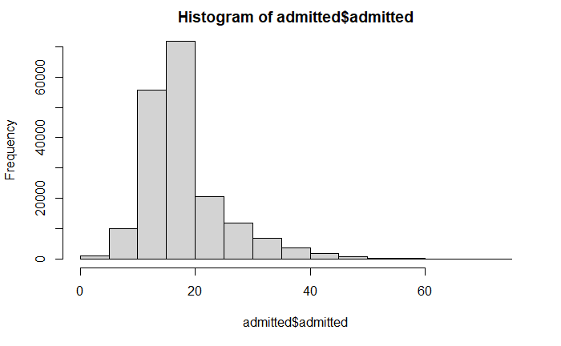

```r
admitted <- na.omit(admitted)
hist(admitted$admitted)
```

```r
dim(admitted)
```

```
[1] 184763     21
```

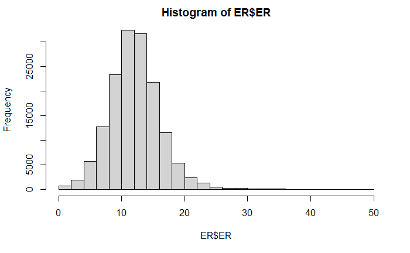

```r
ER <- na.omit(ER)
hist(ER$ER)
```

```r
dim(ER)
```

```
[1] 151409     21
```

Functions for getting the mode and aggregating the data.

```r
getmode <- function(v) {
  levels(v)[which.max(table(v))]
}

my_summary <- function(x, id, na.rm = FALSE){
  if (is.numeric(x)) {
    return(tapply(x, id, mean, na.rm = na.rm))
  }
  if (is.factor(x)) {
    return(tapply(x, id, getmode))
  }
  }


#reference: https://stackoverflow.com/questions/37509714/aggregating-mixed-data-by-factor-column
```

Since linear regression assumes that the observations/records are not dependent on each other I aggregated all the rows belonging to a Home Health Agency such that each Home Health Agency has a single row and fit the model.

Admission Rate Data

```r
data_admitted_CCN <- data.frame(complete_data[,c(2,9:13)],complete_data[,c(15:25)],complete_data[,c(27,30,32,33)])
data_admitted_CCN <- na.omit(data_admitted_CCN)
admittedAggregated <- data.frame(lapply(data_admitted_CCN, my_summary, id=data_admitted_CCN$CCN, na.rm = TRUE))
length(unique(data_admitted_CCN$CCN))
```

```
[1] 10069
```

```r
admittedAggregated <- na.omit(admittedAggregated)
dim(admittedAggregated)
```

```
[1] 10069    21
```

```r
names(admittedAggregated)
```

```
 [1] "CCN"              "off.physical"     "off.occupational" "off.speech"       "off.medical"      "off.hha"
 [7] "timely"           "taughtdrugs"      "checkfall"        "checkdepression"  "pnumococcal"      "taughtfootcare"
[13] "betterbathing"    "lesspain"         "betterbreathing"  "betterdrug"       "admitted"         "episode"
[19] "season"           "median"           "ruca"
```

Function for calculating the Root Mean Squared Error

```r
rmse <- function(error)
{
  sqrt(mean(error^2))
}
```

Emergency Room Visit Data

```r
data_ER_CCN <- data.frame(complete_data[,c(2,9:13)],complete_data[,c(15:24)],complete_data[,c(26,27,30,32,33)])
data_ER_CCN <- na.omit(data_ER_CCN)
ERAggregated <- data.frame(lapply(data_ER_CCN, my_summary, id=data_ER_CCN$CCN, na.rm = TRUE))
length(unique(data_ER_CCN$CCN))
```

```
[1] 9689
```

```r
ERAggregated <- na.omit(ERAggregated)
dim(ERAggregated)
```

```
[1] 9689   21
```

```r
names(ERAggregated)
```

```
 [1] "CCN"              "off.physical"     "off.occupational" "off.speech"       "off.medical"      "off.hha"
 [7] "timely"           "taughtdrugs"      "checkfall"        "checkdepression"  "pnumococcal"      "taughtfootcare"
[13] "betterbathing"    "lesspain"         "betterbreathing"  "betterdrug"       "ER"               "episode"
[19] "season"           "median"           "ruca"
```

Applying Linear Regression Model with Admission Rate as the outcome variable

```r
lm.fit.admitted <- lm(admitted ~ ., data= data.frame(admittedAggregated[,c(2:21)]))
summary(lm.fit.admitted)
```

```
Call:
lm(formula = admitted ~ ., data = data.frame(admittedAggregated[,
    c(2:21)]))

Residuals:
    Min      1Q  Median      3Q     Max
-30.221  -2.420  -0.046   2.178  38.129

Coefficients:
                    Estimate Std. Error t value Pr(>|t|)
(Intercept)        4.099e+01  1.751e+00  23.412  < 2e-16 ***
off.physical1     -1.407e+00  7.285e-01  -1.931 0.053548 .
off.occupational1 -2.737e-02  2.776e-01  -0.099 0.921442
off.speech1        5.169e-01  2.019e-01   2.560 0.010469 *
off.medical1      -4.961e-01  1.573e-01  -3.154 0.001615 **
off.hha1           1.553e+00  2.729e-01   5.690 1.31e-08 ***
timely            -7.638e-03  6.052e-03  -1.262 0.206968
taughtdrugs       -6.702e-02  6.367e-03 -10.526  < 2e-16 ***
checkfall         -1.983e-01  1.511e-02 -13.123  < 2e-16 ***
checkdepression    2.395e-02  6.529e-03   3.668 0.000246 ***
pnumococcal        6.158e-03  2.429e-03   2.535 0.011246 *
taughtfootcare    -9.930e-03  5.562e-03  -1.785 0.074260 .
betterbathing     -1.010e-01  5.313e-03 -19.017  < 2e-16 ***
lesspain          -1.469e-02  4.529e-03  -3.244 0.001182 **
betterbreathing    4.288e-02  4.552e-03   9.421  < 2e-16 ***
betterdrug         5.395e-03  4.814e-03   1.121 0.262464
episode            8.003e-06  9.789e-06   0.818 0.413630
season             3.211e+00  1.531e-01  20.975  < 2e-16 ***
median            -1.150e-05  2.458e-06  -4.680 2.91e-06 ***
rucaUrban         -9.652e-01  1.170e-01  -8.248  < 2e-16 ***
---
Signif. codes:  0 ‘***’ 0.001 ‘**’ 0.01 ‘*’ 0.05 ‘.’ 0.1 ‘ ’ 1

Residual standard error: 4.461 on 10049 degrees of freedom
Multiple R-squared:  0.1689,    Adjusted R-squared:  0.1673
F-statistic: 107.5 on 19 and 10049 DF,  p-value: < 2.2e-16
```

```r
predictedY <- predict(lm.fit.admitted, data.frame(admittedAggregated[,c(2:21)]))
error <- data.frame(admittedAggregated[,c(2:21)])$admitted - predictedY
predictionRMSE <- rmse(error)
predictionRMSE
```

```
[1] 4.456726
```

It seems likely that if any one of the p-values for the individual variables is very small, then at least one of the predictors is related to the response. However, this logic is flawed. Hence, if we use the individual t-statistics and associated p values in order to decide whether or not there is any association between the variables and the response, there is a very high chance that we will incorrectly conclude that there is a relationship[1].

```r
treemodel <- rpart(formula= admitted ~ .,
                model=TRUE,
                data =data.frame(admittedAggregated[,c(2:21)]),cp=0.001, maxdepth = 4
)
#0.002
#0.00019852
summary(treemodel)
```

```
Call:
rpart(formula = admitted ~ ., data = data.frame(admittedAggregated[,
    c(2:21)]), model = TRUE, cp = 0.001, maxdepth = 4)
  n= 10069

            CP nsplit rel error    xerror       xstd
1  0.084111394      0 1.0000000 1.0000475 0.02646157
2  0.044076880      1 0.9158886 0.9168687 0.02544085
3  0.023807003      2 0.8718117 0.8787864 0.02357405
4  0.021671472      3 0.8480047 0.8513849 0.02313919
5  0.012975195      4 0.8263333 0.8393225 0.02297268
6  0.010577140      5 0.8133581 0.8288938 0.02276648
7  0.007272900      6 0.8027809 0.8193422 0.02280401
8  0.006549155      7 0.7955080 0.8192419 0.02290002
9  0.003192672      8 0.7889589 0.8115786 0.02277715
10 0.002957694      9 0.7857662 0.8147627 0.02290811
11 0.002538384     10 0.7828085 0.8127373 0.02283490
12 0.001595771     11 0.7802701 0.8122095 0.02283728
13 0.001529650     12 0.7786743 0.8109297 0.02285767
14 0.001000000     13 0.7771447 0.8113523 0.02290159

Variable importance
         season   betterbathing      betterdrug betterbreathing     taughtdrugs        lesspain  taughtfootcare
             26              18              13              13              10               9               5
      checkfall checkdepression     pnumococcal          timely
              2               1               1               1

Node number 1: 10069 observations,    complexity param=0.08411139
  mean=17.53498, MSE=23.89866
  left son=2 (3268 obs) right son=3 (6801 obs)
  Primary splits:
      season         < 2.412779 to the left,  improve=0.08411139, (0 missing)
      taughtdrugs    < 97.03944 to the right, improve=0.07297925, (0 missing)
      checkfall      < 99.25311 to the right, improve=0.05828153, (0 missing)
      lesspain       < 83.01294 to the right, improve=0.05607312, (0 missing)
      taughtfootcare < 98.38516 to the right, improve=0.05245219, (0 missing)
  Surrogate splits:
      betterbreathing < 77.75857 to the right, agree=0.751, adj=0.232, (0 split)
      betterdrug      < 64.37184 to the right, agree=0.739, adj=0.196, (0 split)
      taughtdrugs     < 99.01893 to the right, agree=0.737, adj=0.191, (0 split)
```

[output cut: 210 more lines]

```

Node number 27: 3390 observations
  mean=18.34206, MSE=9.989773

Node number 28: 343 observations
  mean=16.79462, MSE=41.30778

Node number 29: 822 observations
  mean=19.48376, MSE=34.33491

Node number 30: 427 observations
  mean=19.45523, MSE=11.54494

Node number 31: 807 observations
  mean=22.79906, MSE=54.87664
```

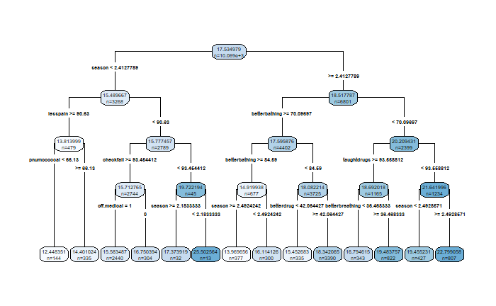

```r
rpart.plot(treemodel,digits=10,fallen.leaves=TRUE,type=4,extra=1)
```

Therefore we need to use F statistic to estimate the p value which helps us conclude if at least one predictor is related to response. But we do not know which variables are important. Therefore we use variable selection methods to determine which predictors are associated with the response.

It is often the case that some or many of the variables used in a multiple regression model are in fact not associated with the response. Including such irrelevant variables leads to unnecessary complexity in the resulting model. By removing these variables—that is, by setting the corresponding coefficient estimates to zero—we can obtain a model that is more easily interpreted. Now least squares is extremely unlikely to yield any coefficient estimates that are exactly zero. [1]

Subset Selection: This approach involves identifying a subset of the p predictors that we believe to be related to the response. We then fit a model using least squares on the reduced set of variables.[1]

Forward Selection: Begins with a model containing no predictors, and then adds predictors to the model, one-at-a-time, until all of the predictors are in the model. In particular, at each step the variable that gives the greatest additional improvement to the fit is added to the model.[1]

```r
regfit.fwd=regsubsets (admitted ~ .,data=data.frame(admittedAggregated[,c(2:21)]) ,nvmax =20,
                        method = "forward")

summary(regfit.fwd)
```

```
Subset selection object
Call: regsubsets.formula(admitted ~ ., data = data.frame(admittedAggregated[,
    c(2:21)]), nvmax = 20, method = "forward")
19 Variables  (and intercept)
                  Forced in Forced out
off.physical1         FALSE      FALSE
off.occupational1     FALSE      FALSE
off.speech1           FALSE      FALSE
off.medical1          FALSE      FALSE
off.hha1              FALSE      FALSE
timely                FALSE      FALSE
taughtdrugs           FALSE      FALSE
checkfall             FALSE      FALSE
checkdepression       FALSE      FALSE
pnumococcal           FALSE      FALSE
taughtfootcare        FALSE      FALSE
betterbathing         FALSE      FALSE
lesspain              FALSE      FALSE
betterbreathing       FALSE      FALSE
betterdrug            FALSE      FALSE
episode               FALSE      FALSE
season                FALSE      FALSE
median                FALSE      FALSE
rucaUrban             FALSE      FALSE
1 subsets of each size up to 19
Selection Algorithm: forward
          off.physical1 off.occupational1 off.speech1 off.medical1 off.hha1 timely taughtdrugs checkfall checkdepression
1  ( 1 )  " "           " "               " "         " "          " "      " "    " "         " "       " "
2  ( 1 )  " "           " "               " "         " "          " "      " "    " "         " "       " "
3  ( 1 )  " "           " "               " "         " "          " "      " "    " "         "*"       " "
4  ( 1 )  " "           " "               " "         " "          " "      " "    " "         "*"       " "
5  ( 1 )  " "           " "               " "         " "          " "      " "    " "         "*"       " "
6  ( 1 )  " "           " "               " "         " "          " "      " "    "*"         "*"       " "
7  ( 1 )  " "           " "               " "         " "          "*"      " "    "*"         "*"       " "
8  ( 1 )  " "           " "               " "         " "          "*"      " "    "*"         "*"       " "
9  ( 1 )  " "           " "               " "         " "          "*"      " "    "*"         "*"       " "
10  ( 1 ) " "           " "               " "         " "          "*"      " "    "*"         "*"       "*"
11  ( 1 ) " "           " "               " "         "*"          "*"      " "    "*"         "*"       "*"
12  ( 1 ) " "           " "               "*"         "*"          "*"      " "    "*"         "*"       "*"
13  ( 1 ) " "           " "               "*"         "*"          "*"      " "    "*"         "*"       "*"
```

[output cut: 11 more lines]

```
5  ( 1 )  " "         " "            "*"           " "      "*"             " "        " "     "*"    " "    "*"
6  ( 1 )  " "         " "            "*"           " "      "*"             " "        " "     "*"    " "    "*"
7  ( 1 )  " "         " "            "*"           " "      "*"             " "        " "     "*"    " "    "*"
8  ( 1 )  " "         " "            "*"           " "      "*"             " "        " "     "*"    "*"    "*"
9  ( 1 )  " "         " "            "*"           "*"      "*"             " "        " "     "*"    "*"    "*"
10  ( 1 ) " "         " "            "*"           "*"      "*"             " "        " "     "*"    "*"    "*"
11  ( 1 ) " "         " "            "*"           "*"      "*"             " "        " "     "*"    "*"    "*"
12  ( 1 ) " "         " "            "*"           "*"      "*"             " "        " "     "*"    "*"    "*"
13  ( 1 ) "*"         " "            "*"           "*"      "*"             " "        " "     "*"    "*"    "*"
14  ( 1 ) "*"         " "            "*"           "*"      "*"             " "        " "     "*"    "*"    "*"
15  ( 1 ) "*"         "*"            "*"           "*"      "*"             " "        " "     "*"    "*"    "*"
16  ( 1 ) "*"         "*"            "*"           "*"      "*"             " "        " "     "*"    "*"    "*"
17  ( 1 ) "*"         "*"            "*"           "*"      "*"             "*"        " "     "*"    "*"    "*"
18  ( 1 ) "*"         "*"            "*"           "*"      "*"             "*"        "*"     "*"    "*"    "*"
19  ( 1 ) "*"         "*"            "*"           "*"      "*"             "*"        "*"     "*"    "*"    "*"
```

```r
reg.summary = summary(regfit.fwd)

reg.summary$rsq
```

```
 [1] 0.05785557 0.09672371 0.12161497 0.13525965 0.14774557 0.15975087 0.16212360 0.16396619 0.16533041 0.16640673 0.16698017
[12] 0.16753886 0.16799989 0.16835294 0.16859179 0.16873281 0.16883440 0.16888957 0.16889037
```

```r
par(mfrow =c(2,2))
plot(reg.summary$rss ,xlab="Number of Variables",ylab="RSS",
       type="l")
plot(reg.summary$adjr2 ,xlab ="Number of Variables",
       ylab="Adjusted RSq",type="l")
```

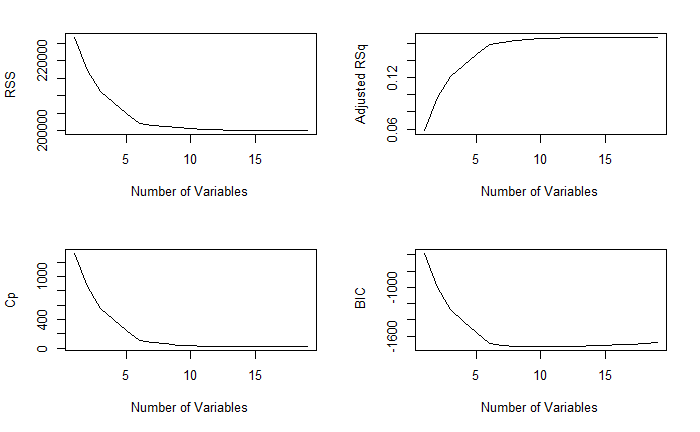

```r
plot(reg.summary$cp ,xlab ="Number of Variables",
     ylab="Cp",type="l")
plot(reg.summary$bic ,xlab=" Number of Variables ",ylab=" BIC", type='l')
```

From the output above, an asterisk specifies that a given variable is included in the corresponding model.

For example, it can be seen that the best 2-variables model contains only betterbathing and season variables (admitted ~ betterbathing + season).

```r
cat("\nThe least BIC value:", which.min(reg.summary$bic))
```

```
The least BIC value: 10
```

Here I am using the BIC criterion which says that the model with 10 features performed better. If we consider other metrics like Cp the model doesn’t show any significant improvement after increasing the features beyond 10.

Displaying the features and their coefficients included in the best 10 variable model.

```r
coef(regfit.fwd, 10)
```

```
    (Intercept)        off.hha1     taughtdrugs       checkfall checkdepression   betterbathing        lesspain
   3.923618e+01    1.511656e+00   -7.018770e-02   -2.011292e-01    2.316964e-02   -9.914008e-02   -1.801106e-02
betterbreathing          season          median       rucaUrban
   4.837882e-02    3.190219e+00   -1.112676e-05   -1.069672e+00
```

Forward selection follows a greedy approach and might include variables early which might become redundant later.

Backward Selection: Unlike forward stepwise selection, it begins with the full least squares model containing all p predictors, and then iteratively removes the least useful predictor, one-at-a-time.

```r
regfit.bwd=regsubsets (admitted ~ .,data=data.frame(admittedAggregated[,c(2:21)]) ,nvmax =20,
                       method = "backward")

summary(regfit.bwd)
```

```
Subset selection object
Call: regsubsets.formula(admitted ~ ., data = data.frame(admittedAggregated[,
    c(2:21)]), nvmax = 20, method = "backward")
19 Variables  (and intercept)
                  Forced in Forced out
off.physical1         FALSE      FALSE
off.occupational1     FALSE      FALSE
off.speech1           FALSE      FALSE
off.medical1          FALSE      FALSE
off.hha1              FALSE      FALSE
timely                FALSE      FALSE
taughtdrugs           FALSE      FALSE
checkfall             FALSE      FALSE
checkdepression       FALSE      FALSE
pnumococcal           FALSE      FALSE
taughtfootcare        FALSE      FALSE
betterbathing         FALSE      FALSE
lesspain              FALSE      FALSE
betterbreathing       FALSE      FALSE
betterdrug            FALSE      FALSE
episode               FALSE      FALSE
season                FALSE      FALSE
median                FALSE      FALSE
rucaUrban             FALSE      FALSE
1 subsets of each size up to 19
Selection Algorithm: backward
          off.physical1 off.occupational1 off.speech1 off.medical1 off.hha1 timely taughtdrugs checkfall checkdepression
1  ( 1 )  " "           " "               " "         " "          " "      " "    " "         " "       " "
2  ( 1 )  " "           " "               " "         " "          " "      " "    " "         " "       " "
3  ( 1 )  " "           " "               " "         " "          " "      " "    " "         "*"       " "
4  ( 1 )  " "           " "               " "         " "          " "      " "    " "         "*"       " "
5  ( 1 )  " "           " "               " "         " "          " "      " "    " "         "*"       " "
6  ( 1 )  " "           " "               " "         " "          " "      " "    "*"         "*"       " "
7  ( 1 )  " "           " "               " "         " "          "*"      " "    "*"         "*"       " "
8  ( 1 )  " "           " "               " "         " "          "*"      " "    "*"         "*"       " "
9  ( 1 )  " "           " "               " "         " "          "*"      " "    "*"         "*"       " "
10  ( 1 ) " "           " "               " "         " "          "*"      " "    "*"         "*"       "*"
11  ( 1 ) " "           " "               " "         "*"          "*"      " "    "*"         "*"       "*"
12  ( 1 ) " "           " "               "*"         "*"          "*"      " "    "*"         "*"       "*"
13  ( 1 ) " "           " "               "*"         "*"          "*"      " "    "*"         "*"       "*"
```

[output cut: 11 more lines]

```
5  ( 1 )  " "         " "            "*"           " "      "*"             " "        " "     "*"    " "    "*"
6  ( 1 )  " "         " "            "*"           " "      "*"             " "        " "     "*"    " "    "*"
7  ( 1 )  " "         " "            "*"           " "      "*"             " "        " "     "*"    " "    "*"
8  ( 1 )  " "         " "            "*"           " "      "*"             " "        " "     "*"    "*"    "*"
9  ( 1 )  " "         " "            "*"           "*"      "*"             " "        " "     "*"    "*"    "*"
10  ( 1 ) " "         " "            "*"           "*"      "*"             " "        " "     "*"    "*"    "*"
11  ( 1 ) " "         " "            "*"           "*"      "*"             " "        " "     "*"    "*"    "*"
12  ( 1 ) " "         " "            "*"           "*"      "*"             " "        " "     "*"    "*"    "*"
13  ( 1 ) "*"         " "            "*"           "*"      "*"             " "        " "     "*"    "*"    "*"
14  ( 1 ) "*"         " "            "*"           "*"      "*"             " "        " "     "*"    "*"    "*"
15  ( 1 ) "*"         "*"            "*"           "*"      "*"             " "        " "     "*"    "*"    "*"
16  ( 1 ) "*"         "*"            "*"           "*"      "*"             " "        " "     "*"    "*"    "*"
17  ( 1 ) "*"         "*"            "*"           "*"      "*"             "*"        " "     "*"    "*"    "*"
18  ( 1 ) "*"         "*"            "*"           "*"      "*"             "*"        "*"     "*"    "*"    "*"
19  ( 1 ) "*"         "*"            "*"           "*"      "*"             "*"        "*"     "*"    "*"    "*"
```

```r
reg.summarybwd = summary(regfit.bwd)

reg.summarybwd$rsq
```

```
 [1] 0.05785557 0.09672371 0.12161497 0.13525965 0.14774557 0.15975087 0.16212360 0.16396619 0.16533041 0.16640673 0.16698017
[12] 0.16753886 0.16799989 0.16835294 0.16859179 0.16873281 0.16883440 0.16888957 0.16889037
```

```r
par(mfrow =c(2,2))
plot(reg.summarybwd$rss ,xlab="Number of Variables",ylab="RSS",
     type="l")
plot(reg.summarybwd$adjr2 ,xlab ="Number of Variables",
     ylab="Adjusted RSq",type="l")
```

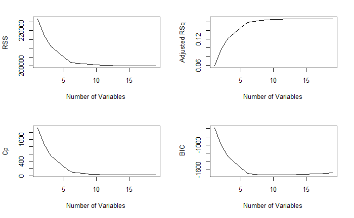

```r
plot(reg.summarybwd$cp ,xlab ="Number of Variables",
     ylab="Cp",type="l")
plot(reg.summarybwd$bic ,xlab=" Number of Variables ",ylab=" BIC", type='l')
```

```r
cat("\nThe least BIC value:", which.min(reg.summarybwd$bic))
```

```
The least BIC value: 10
```

Here I am using the BIC criterion which says that the model with 10 features performed better. If we consider other metrics like Cp the model doesn’t show any significant improvement after increasing the features beyond 10.

Displaying the features and their coefficients included in the best 10 variable model.

```r
coef(regfit.bwd, 10)
```

```
    (Intercept)        off.hha1     taughtdrugs       checkfall checkdepression   betterbathing        lesspain
   3.923618e+01    1.511656e+00   -7.018770e-02   -2.011292e-01    2.316964e-02   -9.914008e-02   -1.801106e-02
betterbreathing          season          median       rucaUrban
   4.837882e-02    3.190219e+00   -1.112676e-05   -1.069672e+00
```

**Cross Validation**

We now try to choose among the models of different sizes using crossvalidation. First, we create a vector that allocates each observation to one of k = 10 folds, and we create a matrix in which we will store the results.

```r
#Reference:An Introduction to Statistical Learning with applications in R. [link](https://www.statlearning.com/)

admittedAggregated <- data.frame(admittedAggregated[,c(2:21)])


predict.regsubsets = function (object ,newdata ,id ,...){
form=as.formula (object$call [[2]])
mat=model.matrix (form ,newdata )
coefi =coef(object ,id=id)
xvars =names (coefi )
mat[,xvars ]%*% coefi
}

k=10
set.seed (1)
folds=sample (1:k,nrow(admittedAggregated),replace =TRUE)
cv.errors.admitted = matrix(NA ,k,19, dimnames =list(NULL, paste (1:19)))

# This has given us a 10×19 matrix, of which the (i, j)th element corresponds
# to the test MSE for the ith cross-validation fold for the best j-variable
# model. We use the apply() function to average over the columns of this
# apply()
# matrix in order to obtain a vector for which the jth element is the crossvalidation
# error for the j-variable model.

for(j in 1:k){
best.fit.admitted =regsubsets (admitted ~ .,data= admittedAggregated[folds!=j,],
                          nvmax =19)
for(i in 1:19) {
  pred=predict(best.fit.admitted ,admittedAggregated[folds ==j,], id=i)
  cv.errors.admitted[j,i]=mean((admittedAggregated$admitted[folds ==j]-pred)^2)
  }
}

mean.cv.errors.admitted =apply(cv.errors.admitted ,2, mean)
mean.cv.errors.admitted
```

```
       1        2        3        4        5        6        7        8        9       10       11       12       13
22.57083 21.64527 21.05869 20.94134 20.65274 20.17064 20.13772 20.13643 20.10673 20.08383 20.11732 20.11682 20.13469
      14       15       16       17       18       19
20.10851 20.11051 20.10837 20.10433 20.10635 20.10359
```

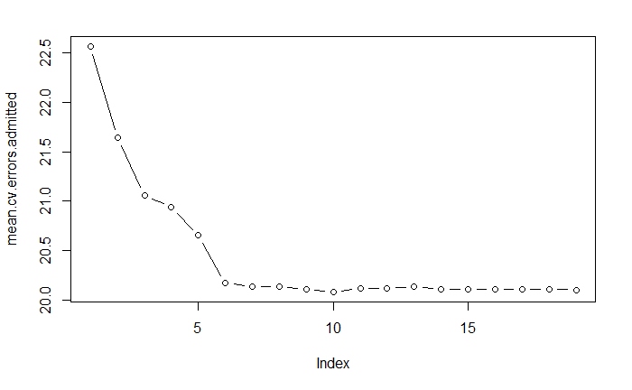

```r
par(mfrow =c(1,1))
plot(mean.cv.errors.admitted ,type='b')
```

```r
which.min(mean.cv.errors.admitted)
```

```
10
10
```

We see that cross-validation selects a 10-variable model. We now perform best subset selection on the full data set in order to obtain the 10-variable model.

```r
reg.best = regsubsets(admitted ~ ., data = admittedAggregated, nvmax =19)
coef(reg.best ,10)
```

```
    (Intercept)        off.hha1     taughtdrugs       checkfall checkdepression   betterbathing        lesspain
   3.923618e+01    1.511656e+00   -7.018770e-02   -2.011292e-01    2.316964e-02   -9.914008e-02   -1.801106e-02
betterbreathing          season          median       rucaUrban
   4.837882e-02    3.190219e+00   -1.112676e-05   -1.069672e+00
```

*Similarly Applying variable selection techjniques to understand which predictirs are related to Emergency Room Visit Rate*

Forward Selection

```r
regfit.fwd=regsubsets (ER ~ .,data=data.frame(ERAggregated[,c(2:21)]) ,nvmax =20,
                        method = "forward")

summary(regfit.fwd)
```

```
Subset selection object
Call: regsubsets.formula(ER ~ ., data = data.frame(ERAggregated[, c(2:21)]),
    nvmax = 20, method = "forward")
19 Variables  (and intercept)
                  Forced in Forced out
off.physical1         FALSE      FALSE
off.occupational1     FALSE      FALSE
off.speech1           FALSE      FALSE
off.medical1          FALSE      FALSE
off.hha1              FALSE      FALSE
timely                FALSE      FALSE
taughtdrugs           FALSE      FALSE
checkfall             FALSE      FALSE
checkdepression       FALSE      FALSE
pnumococcal           FALSE      FALSE
taughtfootcare        FALSE      FALSE
betterbathing         FALSE      FALSE
lesspain              FALSE      FALSE
betterbreathing       FALSE      FALSE
betterdrug            FALSE      FALSE
episode               FALSE      FALSE
season                FALSE      FALSE
median                FALSE      FALSE
rucaUrban             FALSE      FALSE
1 subsets of each size up to 19
Selection Algorithm: forward
          off.physical1 off.occupational1 off.speech1 off.medical1 off.hha1 timely taughtdrugs checkfall checkdepression
1  ( 1 )  " "           " "               " "         " "          " "      " "    " "         " "       " "
2  ( 1 )  " "           " "               " "         " "          " "      " "    " "         " "       " "
3  ( 1 )  " "           " "               " "         " "          " "      " "    " "         " "       " "
4  ( 1 )  " "           " "               " "         " "          " "      " "    " "         " "       " "
5  ( 1 )  " "           " "               " "         " "          " "      " "    " "         " "       " "
6  ( 1 )  " "           " "               " "         " "          " "      " "    " "         " "       " "
7  ( 1 )  " "           " "               " "         " "          " "      " "    " "         "*"       " "
8  ( 1 )  " "           " "               " "         " "          " "      " "    " "         "*"       " "
9  ( 1 )  " "           " "               " "         " "          " "      " "    "*"         "*"       " "
10  ( 1 ) " "           " "               " "         "*"          " "      " "    "*"         "*"       " "
11  ( 1 ) " "           " "               " "         "*"          " "      "*"    "*"         "*"       " "
12  ( 1 ) " "           " "               " "         "*"          " "      "*"    "*"         "*"       "*"
13  ( 1 ) " "           " "               " "         "*"          " "      "*"    "*"         "*"       "*"
```

[output cut: 11 more lines]

```
5  ( 1 )  "*"         " "            " "           "*"      "*"             "*"        " "     " "    " "    "*"
6  ( 1 )  "*"         " "            " "           "*"      "*"             "*"        " "     "*"    " "    "*"
7  ( 1 )  "*"         " "            " "           "*"      "*"             "*"        " "     "*"    " "    "*"
8  ( 1 )  "*"         " "            " "           "*"      "*"             "*"        " "     "*"    "*"    "*"
9  ( 1 )  "*"         " "            " "           "*"      "*"             "*"        " "     "*"    "*"    "*"
10  ( 1 ) "*"         " "            " "           "*"      "*"             "*"        " "     "*"    "*"    "*"
11  ( 1 ) "*"         " "            " "           "*"      "*"             "*"        " "     "*"    "*"    "*"
12  ( 1 ) "*"         " "            " "           "*"      "*"             "*"        " "     "*"    "*"    "*"
13  ( 1 ) "*"         " "            "*"           "*"      "*"             "*"        " "     "*"    "*"    "*"
14  ( 1 ) "*"         " "            "*"           "*"      "*"             "*"        " "     "*"    "*"    "*"
15  ( 1 ) "*"         " "            "*"           "*"      "*"             "*"        " "     "*"    "*"    "*"
16  ( 1 ) "*"         " "            "*"           "*"      "*"             "*"        " "     "*"    "*"    "*"
17  ( 1 ) "*"         " "            "*"           "*"      "*"             "*"        "*"     "*"    "*"    "*"
18  ( 1 ) "*"         "*"            "*"           "*"      "*"             "*"        "*"     "*"    "*"    "*"
19  ( 1 ) "*"         "*"            "*"           "*"      "*"             "*"        "*"     "*"    "*"    "*"
```

```r
reg.summary = summary(regfit.fwd)

reg.summary$rsq
```

```
 [1] 0.09842294 0.12391298 0.14466623 0.17273598 0.17744863 0.18029505 0.18216425 0.18368938 0.18452375 0.18502130 0.18546752
[12] 0.18572543 0.18582013 0.18586340 0.18591897 0.18595755 0.18597868 0.18599244 0.18599278
```

```r
par(mfrow =c(2,2))
plot(reg.summary$rss ,xlab="Number of Variables",ylab="RSS",
       type="l")
plot(reg.summary$adjr2 ,xlab ="Number of Variables",
       ylab="Adjusted RSq",type="l")
```

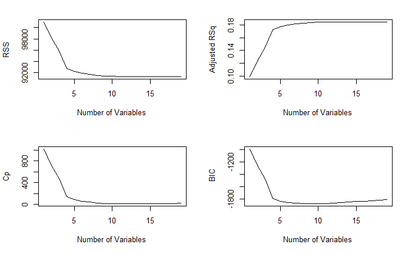

```r
plot(reg.summary$cp ,xlab ="Number of Variables",
     ylab="Cp",type="l")
plot(reg.summary$bic ,xlab=" Number of Variables ",ylab=" BIC", type='l')
```

```r
cat("\nThe least BIC value:", which.min(reg.summary$bic))
```

```
The least BIC value: 9
```

Displaying the features and their coefficients included in the best 9 variable model for the Emergency Room Visit Rate.

```r
coef(regfit.fwd, 9)
```

```
    (Intercept)     taughtdrugs       checkfall     pnumococcal        lesspain betterbreathing      betterdrug
   2.202830e+01   -1.394088e-02   -5.264609e-02    2.025675e-02   -6.569517e-02    3.217139e-02    2.025337e-02
         season          median       rucaUrban
  -6.361382e-01   -7.307818e-06   -1.887844e+00
```

Backward Selection

```r
regfit.bwd=regsubsets (ER ~ .,data=data.frame(ERAggregated[,c(2:21)]) ,nvmax =20,
                       method = "backward")

summary(regfit.bwd)
```

```
Subset selection object
Call: regsubsets.formula(ER ~ ., data = data.frame(ERAggregated[, c(2:21)]),
    nvmax = 20, method = "backward")
19 Variables  (and intercept)
                  Forced in Forced out
off.physical1         FALSE      FALSE
off.occupational1     FALSE      FALSE
off.speech1           FALSE      FALSE
off.medical1          FALSE      FALSE
off.hha1              FALSE      FALSE
timely                FALSE      FALSE
taughtdrugs           FALSE      FALSE
checkfall             FALSE      FALSE
checkdepression       FALSE      FALSE
pnumococcal           FALSE      FALSE
taughtfootcare        FALSE      FALSE
betterbathing         FALSE      FALSE
lesspain              FALSE      FALSE
betterbreathing       FALSE      FALSE
betterdrug            FALSE      FALSE
episode               FALSE      FALSE
season                FALSE      FALSE
median                FALSE      FALSE
rucaUrban             FALSE      FALSE
1 subsets of each size up to 19
Selection Algorithm: backward
          off.physical1 off.occupational1 off.speech1 off.medical1 off.hha1 timely taughtdrugs checkfall checkdepression
1  ( 1 )  " "           " "               " "         " "          " "      " "    " "         " "       " "
2  ( 1 )  " "           " "               " "         " "          " "      " "    " "         " "       " "
3  ( 1 )  " "           " "               " "         " "          " "      " "    " "         " "       " "
4  ( 1 )  " "           " "               " "         " "          " "      " "    " "         " "       " "
5  ( 1 )  " "           " "               " "         " "          " "      " "    " "         " "       " "
6  ( 1 )  " "           " "               " "         " "          " "      " "    " "         " "       " "
7  ( 1 )  " "           " "               " "         " "          " "      " "    " "         "*"       " "
8  ( 1 )  " "           " "               " "         " "          " "      " "    " "         "*"       " "
9  ( 1 )  " "           " "               " "         " "          " "      " "    "*"         "*"       " "
10  ( 1 ) " "           " "               " "         "*"          " "      " "    "*"         "*"       " "
11  ( 1 ) " "           " "               " "         "*"          " "      "*"    "*"         "*"       " "
12  ( 1 ) " "           " "               " "         "*"          " "      "*"    "*"         "*"       "*"
13  ( 1 ) " "           " "               " "         "*"          " "      "*"    "*"         "*"       "*"
```

[output cut: 11 more lines]

```
5  ( 1 )  "*"         " "            " "           "*"      "*"             "*"        " "     " "    " "    "*"
6  ( 1 )  "*"         " "            " "           "*"      "*"             "*"        " "     "*"    " "    "*"
7  ( 1 )  "*"         " "            " "           "*"      "*"             "*"        " "     "*"    " "    "*"
8  ( 1 )  "*"         " "            " "           "*"      "*"             "*"        " "     "*"    "*"    "*"
9  ( 1 )  "*"         " "            " "           "*"      "*"             "*"        " "     "*"    "*"    "*"
10  ( 1 ) "*"         " "            " "           "*"      "*"             "*"        " "     "*"    "*"    "*"
11  ( 1 ) "*"         " "            " "           "*"      "*"             "*"        " "     "*"    "*"    "*"
12  ( 1 ) "*"         " "            " "           "*"      "*"             "*"        " "     "*"    "*"    "*"
13  ( 1 ) "*"         " "            "*"           "*"      "*"             "*"        " "     "*"    "*"    "*"
14  ( 1 ) "*"         " "            "*"           "*"      "*"             "*"        " "     "*"    "*"    "*"
15  ( 1 ) "*"         " "            "*"           "*"      "*"             "*"        " "     "*"    "*"    "*"
16  ( 1 ) "*"         " "            "*"           "*"      "*"             "*"        " "     "*"    "*"    "*"
17  ( 1 ) "*"         " "            "*"           "*"      "*"             "*"        "*"     "*"    "*"    "*"
18  ( 1 ) "*"         "*"            "*"           "*"      "*"             "*"        "*"     "*"    "*"    "*"
19  ( 1 ) "*"         "*"            "*"           "*"      "*"             "*"        "*"     "*"    "*"    "*"
```

```r
reg.summarybwd = summary(regfit.bwd)

reg.summarybwd$rsq
```

```
 [1] 0.09842294 0.11324238 0.15892441 0.17273598 0.17744863 0.18029505 0.18216425 0.18368938 0.18452375 0.18502130 0.18546752
[12] 0.18572543 0.18582013 0.18586340 0.18591897 0.18595755 0.18597868 0.18599244 0.18599278
```

```r
par(mfrow =c(2,2))
plot(reg.summarybwd$rss ,xlab="Number of Variables",ylab="RSS",
     type="l")
plot(reg.summarybwd$adjr2 ,xlab ="Number of Variables",
     ylab="Adjusted RSq",type="l")
```

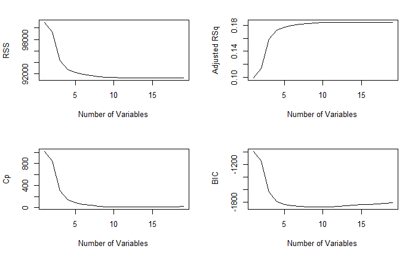

```r
plot(reg.summarybwd$cp ,xlab ="Number of Variables",
     ylab="Cp",type="l")
plot(reg.summarybwd$bic ,xlab=" Number of Variables ",ylab=" BIC", type='l')
```

```r
cat("\nThe least BIC value:", which.min(reg.summarybwd$bic))
```

```
The least BIC value: 9
```

Displaying the features and their coefficients included in the best 9 variable model for the Emergency Room Visit Rate.

```r
coef(regfit.bwd, 9)
```

```
    (Intercept)     taughtdrugs       checkfall     pnumococcal        lesspain betterbreathing      betterdrug
   2.202830e+01   -1.394088e-02   -5.264609e-02    2.025675e-02   -6.569517e-02    3.217139e-02    2.025337e-02
         season          median       rucaUrban
  -6.361382e-01   -7.307818e-06   -1.887844e+00
```

Cross Validation Approach

```r
ERAggregated <- data.frame(ERAggregated[,c(2:21)])

k=10
set.seed (1)
folds=sample (1:k,nrow(ERAggregated),replace =TRUE)
cv.errors.ER = matrix(NA ,k,19, dimnames =list(NULL, paste (1:19)))

for(j in 1:k){
best.fit.ER =regsubsets (ER ~ .,data= ERAggregated[folds!=j,],
                          nvmax =19)
for(i in 1:19) {
  pred=predict(best.fit.ER ,ERAggregated[folds ==j,], id=i)
  cv.errors.ER[j,i]=mean((ERAggregated$ER[folds ==j]-pred)^2)
  }
}

mean.cv.errors.ER =apply(cv.errors.ER ,2, mean)
mean.cv.errors.ER
```

```
        1         2         3         4         5         6         7         8         9        10        11        12
10.436309 10.144386  9.750241  9.592735  9.547077  9.509556  9.493008  9.482949  9.478287  9.477861  9.471258  9.468230
       13        14        15        16        17        18        19
 9.473274  9.479650  9.483955  9.485432  9.485463  9.483962  9.483805
```

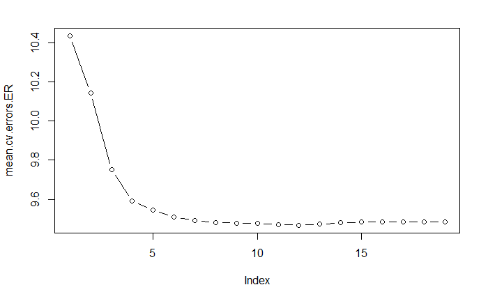

```r
par(mfrow =c(1,1))
plot(mean.cv.errors.ER ,type='b')
```

```r
which.min(mean.cv.errors.ER)
```

```
12
12
```

We see that cross-validation selects a 12-variable model. We now perform best subset selection on the full data set in order to obtain the 12-variable model.

```r
reg.best = regsubsets(ER ~ ., data = ERAggregated, nvmax =19)
coef(reg.best ,12)
```

```
    (Intercept)    off.medical1          timely     taughtdrugs       checkfall checkdepression     pnumococcal
   2.297343e+01   -2.530187e-01   -9.784850e-03   -1.057119e-02   -4.691226e-02   -9.069444e-03    2.102826e-02
       lesspain betterbreathing      betterdrug          season          median       rucaUrban
  -6.378804e-02    3.160649e-02    2.068184e-02   -6.435277e-01   -7.356977e-06   -1.862144e+00
```

**PreCovid and Covid Timeframe comparison**

```r
dim(complete_data)
```

```
[1] 477164     33
```

```r
dim(admitted)
```

```
[1] 184763     21
```

Creating seperate dataframes for precovid and after covid.

```r
data_precovid <- subset(complete_data, timeindex < 40)
dim(data_precovid)
```

```
[1] 421002     33
```

```r
data_covid <- subset(complete_data, timeindex >= 40)
dim(data_covid)
```

```
[1] 56162    33
```

Admission Rate Data Precovid

```r
data_admitted_CCN_precovid <- data.frame(data_precovid[,c(2,9:13)],data_precovid[,c(15:25)],data_precovid[,c(27,30,32,33)])
data_admitted_CCN_precovid <- na.omit(data_admitted_CCN_precovid)
admittedAggregatedPrecovid <- data.frame(lapply(data_admitted_CCN_precovid, my_summary, id=data_admitted_CCN_precovid$CCN, na.rm = TRUE))
length(unique(data_admitted_CCN_precovid$CCN))
```

```
[1] 9869
```

```r
admittedAggregatedPrecovid <- na.omit(admittedAggregatedPrecovid)
dim(admittedAggregatedPrecovid)
```

```
[1] 9869   21
```

```r
names(admittedAggregatedPrecovid)
```

```
 [1] "CCN"              "off.physical"     "off.occupational" "off.speech"       "off.medical"      "off.hha"
 [7] "timely"           "taughtdrugs"      "checkfall"        "checkdepression"  "pnumococcal"      "taughtfootcare"
[13] "betterbathing"    "lesspain"         "betterbreathing"  "betterdrug"       "admitted"         "episode"
[19] "season"           "median"           "ruca"
```

Applying backward selection method for pre covid data to understand which predictors are related to the admission rate.

```r
regfit.bwd=regsubsets (admitted ~ .,data=data.frame(admittedAggregatedPrecovid[,c(2:21)]) ,nvmax =20,
                       method = "backward")

summary(regfit.bwd)
```

```
Subset selection object
Call: regsubsets.formula(admitted ~ ., data = data.frame(admittedAggregatedPrecovid[,
    c(2:21)]), nvmax = 20, method = "backward")
19 Variables  (and intercept)
                  Forced in Forced out
off.physical1         FALSE      FALSE
off.occupational1     FALSE      FALSE
off.speech1           FALSE      FALSE
off.medical1          FALSE      FALSE
off.hha1              FALSE      FALSE
timely                FALSE      FALSE
taughtdrugs           FALSE      FALSE
checkfall             FALSE      FALSE
checkdepression       FALSE      FALSE
pnumococcal           FALSE      FALSE
taughtfootcare        FALSE      FALSE
betterbathing         FALSE      FALSE
lesspain              FALSE      FALSE
betterbreathing       FALSE      FALSE
betterdrug            FALSE      FALSE
episode               FALSE      FALSE
season                FALSE      FALSE
median                FALSE      FALSE
rucaUrban             FALSE      FALSE
1 subsets of each size up to 19
Selection Algorithm: backward
          off.physical1 off.occupational1 off.speech1 off.medical1 off.hha1 timely taughtdrugs checkfall checkdepression
1  ( 1 )  " "           " "               " "         " "          " "      " "    " "         " "       " "
2  ( 1 )  " "           " "               " "         " "          " "      " "    " "         " "       " "
3  ( 1 )  " "           " "               " "         " "          " "      " "    " "         " "       " "
4  ( 1 )  " "           " "               " "         " "          " "      " "    " "         "*"       " "
5  ( 1 )  " "           " "               " "         " "          " "      " "    " "         "*"       " "
6  ( 1 )  " "           " "               " "         " "          " "      " "    "*"         "*"       " "
7  ( 1 )  " "           " "               " "         " "          " "      " "    "*"         "*"       " "
8  ( 1 )  " "           " "               " "         " "          "*"      " "    "*"         "*"       " "
9  ( 1 )  " "           " "               " "         " "          "*"      " "    "*"         "*"       " "
10  ( 1 ) " "           " "               " "         "*"          "*"      " "    "*"         "*"       " "
11  ( 1 ) " "           " "               " "         "*"          "*"      " "    "*"         "*"       " "
12  ( 1 ) " "           " "               " "         "*"          "*"      " "    "*"         "*"       " "
13  ( 1 ) " "           " "               " "         "*"          "*"      " "    "*"         "*"       "*"
```

[output cut: 11 more lines]

```
5  ( 1 )  " "         " "            "*"           " "      "*"             " "        " "     "*"    " "    "*"
6  ( 1 )  " "         " "            "*"           " "      "*"             " "        " "     "*"    " "    "*"
7  ( 1 )  " "         " "            "*"           " "      "*"             " "        " "     "*"    "*"    "*"
8  ( 1 )  " "         " "            "*"           " "      "*"             " "        " "     "*"    "*"    "*"
9  ( 1 )  " "         " "            "*"           " "      "*"             "*"        " "     "*"    "*"    "*"
10  ( 1 ) " "         " "            "*"           " "      "*"             "*"        " "     "*"    "*"    "*"
11  ( 1 ) "*"         " "            "*"           " "      "*"             "*"        " "     "*"    "*"    "*"
12  ( 1 ) "*"         " "            "*"           "*"      "*"             "*"        " "     "*"    "*"    "*"
13  ( 1 ) "*"         " "            "*"           "*"      "*"             "*"        " "     "*"    "*"    "*"
14  ( 1 ) "*"         " "            "*"           "*"      "*"             "*"        " "     "*"    "*"    "*"
15  ( 1 ) "*"         " "            "*"           "*"      "*"             "*"        " "     "*"    "*"    "*"
16  ( 1 ) "*"         "*"            "*"           "*"      "*"             "*"        " "     "*"    "*"    "*"
17  ( 1 ) "*"         "*"            "*"           "*"      "*"             "*"        " "     "*"    "*"    "*"
18  ( 1 ) "*"         "*"            "*"           "*"      "*"             "*"        "*"     "*"    "*"    "*"
19  ( 1 ) "*"         "*"            "*"           "*"      "*"             "*"        "*"     "*"    "*"    "*"
```

```r
reg.summarybwd = summary(regfit.bwd)

reg.summarybwd$rsq
```

```
 [1] 0.06564055 0.10742878 0.13251166 0.15261661 0.16558241 0.17382569 0.17515105 0.17652403 0.17775251 0.17868432 0.17953728
[12] 0.18013385 0.18057156 0.18091856 0.18124828 0.18135973 0.18144801 0.18150163 0.18155066
```

```r
par(mfrow =c(2,2))
plot(reg.summarybwd$rss ,xlab="Number of Variables",ylab="RSS",
     type="l")
plot(reg.summarybwd$adjr2 ,xlab ="Number of Variables",
     ylab="Adjusted RSq",type="l")
```

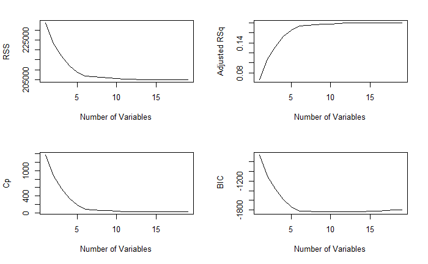

```r
plot(reg.summarybwd$cp ,xlab ="Number of Variables",
     ylab="Cp",type="l")
plot(reg.summarybwd$bic ,xlab=" Number of Variables ",ylab=" BIC", type='l')
```

```r
cat("\nThe least BIC value:", which.min(reg.summarybwd$bic))
```

```
The least BIC value: 11
```

Displaying the features and their coefficients included in the best 11 variable model for the admission rate **precovid**.

```r
coef(regfit.bwd,11)
```

```
    (Intercept)    off.medical1        off.hha1     taughtdrugs       checkfall     pnumococcal   betterbathing
   3.791261e+01   -5.418242e-01    1.371977e+00   -5.913593e-02   -1.900700e-01    7.732754e-03   -1.208422e-01
betterbreathing      betterdrug          season          median       rucaUrban
   4.302089e-02    1.904352e-02    3.781068e+00   -1.053491e-05   -1.062515e+00
```

Admission Rate Data after covid

```r
data_admitted_CCN_covid <- data.frame(data_covid[,c(2,9:13)],data_covid[,c(15:25)],data_covid[,c(27,30,32,33)])
data_admitted_CCN_covid <- na.omit(data_admitted_CCN_covid)
admittedAggregatedCovid <- data.frame(lapply(data_admitted_CCN_covid, my_summary, id=data_admitted_CCN_covid$CCN, na.rm = TRUE))
length(unique(data_admitted_CCN_covid$CCN))
```

```
[1] 7112
```

```r
admittedAggregatedCovid <- na.omit(admittedAggregatedCovid)
dim(admittedAggregatedCovid)
```

```
[1] 7112   21
```

```r
names(admittedAggregatedCovid)
```

```
 [1] "CCN"              "off.physical"     "off.occupational" "off.speech"       "off.medical"      "off.hha"
 [7] "timely"           "taughtdrugs"      "checkfall"        "checkdepression"  "pnumococcal"      "taughtfootcare"
[13] "betterbathing"    "lesspain"         "betterbreathing"  "betterdrug"       "admitted"         "episode"
[19] "season"           "median"           "ruca"
```

Applying backward selection method for covid data to understand which predictors are related to the admission rate.

```r
regfit.bwd=regsubsets (admitted ~ .,data=data.frame(admittedAggregatedCovid[,c(2:21)]) ,nvmax =20,
                       method = "backward")

summary(regfit.bwd)
```

```
Subset selection object
Call: regsubsets.formula(admitted ~ ., data = data.frame(admittedAggregatedCovid[,
    c(2:21)]), nvmax = 20, method = "backward")
19 Variables  (and intercept)
                  Forced in Forced out
off.physical1         FALSE      FALSE
off.occupational1     FALSE      FALSE
off.speech1           FALSE      FALSE
off.medical1          FALSE      FALSE
off.hha1              FALSE      FALSE
timely                FALSE      FALSE
taughtdrugs           FALSE      FALSE
checkfall             FALSE      FALSE
checkdepression       FALSE      FALSE
pnumococcal           FALSE      FALSE
taughtfootcare        FALSE      FALSE
betterbathing         FALSE      FALSE
lesspain              FALSE      FALSE
betterbreathing       FALSE      FALSE
betterdrug            FALSE      FALSE
episode               FALSE      FALSE
season                FALSE      FALSE
median                FALSE      FALSE
rucaUrban             FALSE      FALSE
1 subsets of each size up to 19
Selection Algorithm: backward
          off.physical1 off.occupational1 off.speech1 off.medical1 off.hha1 timely taughtdrugs checkfall checkdepression
1  ( 1 )  " "           " "               " "         " "          " "      " "    " "         " "       " "
2  ( 1 )  " "           " "               " "         " "          " "      " "    " "         " "       " "
3  ( 1 )  " "           " "               " "         " "          " "      " "    " "         " "       " "
4  ( 1 )  " "           " "               " "         " "          " "      " "    " "         " "       " "
5  ( 1 )  " "           " "               " "         " "          " "      " "    " "         " "       " "
6  ( 1 )  " "           " "               " "         " "          " "      " "    " "         " "       " "
7  ( 1 )  " "           " "               " "         " "          " "      "*"    " "         " "       " "
8  ( 1 )  " "           " "               " "         " "          " "      "*"    " "         " "       " "
9  ( 1 )  " "           " "               " "         " "          "*"      "*"    " "         " "       " "
10  ( 1 ) " "           " "               " "         "*"          "*"      "*"    " "         " "       " "
11  ( 1 ) " "           " "               " "         "*"          "*"      "*"    " "         "*"       " "
12  ( 1 ) " "           " "               " "         "*"          "*"      "*"    " "         "*"       "*"
13  ( 1 ) " "           " "               " "         "*"          "*"      "*"    "*"         "*"       "*"
```

[output cut: 11 more lines]

```
5  ( 1 )  "*"         " "            " "           " "      "*"             " "        "*"     " "    "*"    "*"
6  ( 1 )  "*"         " "            "*"           " "      "*"             " "        "*"     " "    "*"    "*"
7  ( 1 )  "*"         " "            "*"           " "      "*"             " "        "*"     " "    "*"    "*"
8  ( 1 )  "*"         " "            "*"           " "      "*"             " "        "*"     "*"    "*"    "*"
9  ( 1 )  "*"         " "            "*"           " "      "*"             " "        "*"     "*"    "*"    "*"
10  ( 1 ) "*"         " "            "*"           " "      "*"             " "        "*"     "*"    "*"    "*"
11  ( 1 ) "*"         " "            "*"           " "      "*"             " "        "*"     "*"    "*"    "*"
12  ( 1 ) "*"         " "            "*"           " "      "*"             " "        "*"     "*"    "*"    "*"
13  ( 1 ) "*"         " "            "*"           " "      "*"             " "        "*"     "*"    "*"    "*"
14  ( 1 ) "*"         " "            "*"           "*"      "*"             " "        "*"     "*"    "*"    "*"
15  ( 1 ) "*"         " "            "*"           "*"      "*"             "*"        "*"     "*"    "*"    "*"
16  ( 1 ) "*"         " "            "*"           "*"      "*"             "*"        "*"     "*"    "*"    "*"
17  ( 1 ) "*"         " "            "*"           "*"      "*"             "*"        "*"     "*"    "*"    "*"
18  ( 1 ) "*"         "*"            "*"           "*"      "*"             "*"        "*"     "*"    "*"    "*"
19  ( 1 ) "*"         "*"            "*"           "*"      "*"             "*"        "*"     "*"    "*"    "*"
```

```r
reg.summarybwd = summary(regfit.bwd)

reg.summarybwd$rsq
```

```
 [1] 0.01376592 0.02364889 0.02687024 0.02958043 0.03025384 0.03118739 0.03202652 0.03274472 0.03343752 0.03391758 0.03428543
[12] 0.03469628 0.03505432 0.03537204 0.03569403 0.03597662 0.03611236 0.03620346 0.03620368
```

```r
par(mfrow =c(2,2))
plot(reg.summarybwd$rss ,xlab="Number of Variables",ylab="RSS",
     type="l")
plot(reg.summarybwd$adjr2 ,xlab ="Number of Variables",
     ylab="Adjusted RSq",type="l")
```

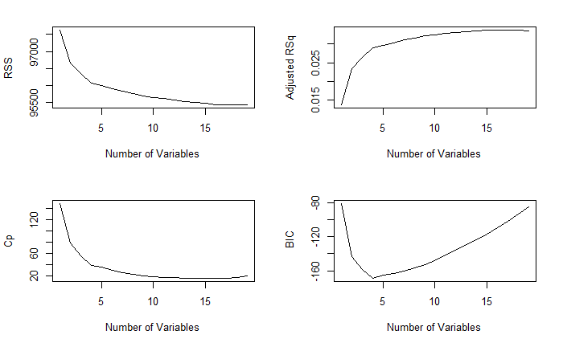

```r
plot(reg.summarybwd$cp ,xlab ="Number of Variables",
     ylab="Cp",type="l")
plot(reg.summarybwd$bic ,xlab=" Number of Variables ",ylab=" BIC", type='l')
```

```r
cat("\nThe least BIC value:", which.min(reg.summarybwd$bic))
```

```
The least BIC value: 4
```

Displaying the features and their coefficients included in the best 4 variable model for the admission rate **after covid**.

```r
coef(regfit.bwd,4)
```

```
  (Intercept)   pnumococcal       episode        median     rucaUrban
 1.445864e+01  2.047035e-02  1.172099e-04 -1.025411e-05 -7.155088e-01
```

**References**

1. An Introduction to Statistical Learning with applications in R. [link](https://www.statlearning.com/)